# LAB 1

# A little statistics

1.Converting a probability into a 'sigma'.

```python
%matplotlib inline
import numpy as np
import matplotlib
import matplotlib.pyplot as plt
import scipy
from scipy import stats
from scipy.stats import binom
```

1.B

```python
stats.norm.cdf(1.6)
```

```
0.945200708300442
```

```python
stats.norm.cdf(1.0)
```

```
0.8413447460685429
```

```python
stats.norm.cdf(0.0)
```

```
0.5
```

1.C

```python
stats.norm.ppf(0.945200708300442)
```

```
1.6000000000000003
```

```python
stats.norm.ppf(0.8413447460685429)
```

```
1.0
```

```python
stats.norm.ppf(0.5)
```

```
0.0
```

2.Some other distributions

```python
d = stats.rayleigh.rvs(loc = 5., scale = 0.01, size = 100000)
```

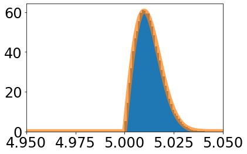

```python
fig, ax = plt.subplots(1, 1)
ax.hist(d,50, density=True)
plt.tick_params(labelsize = 24)
plt.xlim([4.95,5.05])
x = np.linspace(4.95,5.05,1000)
ax.plot(x,stats.rayleigh.pdf(x,loc = 5., scale = 0.01),linewidth = 8,alpha = 0.7)
plt.show()
```

3.Signal free data

3a:5.010

3B:What is the probability of 5.010 is a signal?

3D:

```python
stats.rayleigh.cdf(5.010,loc = 5., scale = 0.01)
```

```
0.39346934028735364
```

3E:

```python
stats.rayleigh.ppf(0.39346934028735364,loc = 5., scale = 0.01)
```

```
5.01
```

4.Pick 4.95 and 5.05

4.95:

```python
stats.rayleigh.cdf(4.95,loc = 5., scale = 0.01)
```

```
0.0
```

```python
stats.rayleigh.ppf(0,loc = 5., scale = 0.01)
```

```
5.0
```

5.05:

```python
stats.rayleigh.cdf(5.05,loc = 5., scale = 0.01)
```

```
0.999996273346828
```

```python
stats.rayleigh.ppf(0.999996273346828,loc = 5., scale = 0.01)
```

```
5.050000000000013
```

Pattern:Because everything below 5.0 has a probability of 0 so it would just show that the probablity at 5 is zero.

# Non-continuous distributions

1B:

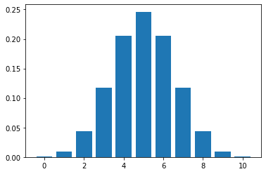

```python
n = 10
p = 0.5
length = list(range(n + 1))
dist = [binom.pmf(i, n, p) for i in length]
plt.bar(length, dist)
plt.show()
```

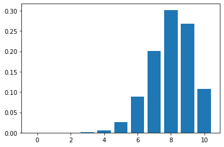

```python
n = 10
p = 0.8
length = list(range(n + 1))
dist = [binom.pmf(i, n, p) for i in length]
plt.bar(length, dist)
plt.show()
```

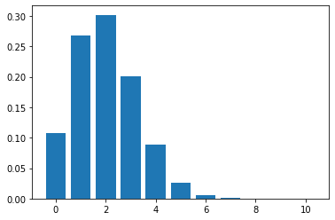

```python
n = 10
p = 0.2
length = list(range(n + 1))
dist = [binom.pmf(i, n, p) for i in length]
plt.bar(length, dist)
plt.show()
```

Features:The probability is highest when at the n*p point.

1C.When we have 10 independent experiments and the success probability is 0.2, what is the probability that the experiment success less or equal than 5 times?

```python
binom.cdf(5, 10, 0.2)
```

```
0.9936306176
```

```python
binom.ppf(0.9936306176, 10, 0.2)
```

```
5.0
```

1D:Because the distributions are discrete, it means the probability curve is not smooth and only have a stair like probability. Because of that experiment might have a big difference probability and we can use that to choose a relative high probability number.

1E:Because mean equals to the sum of a collegetion divided by the count of numbers in the collection so it is very possible it would have a number that perfectly devided by the number of experiments.